# IE425project

SEYMA CAKIR

30 06 2021

# PROJECT REPORT

## Necati Aras, IE 425

**Import Data**

```r
library(lubridate)
library(data.table)
library(dplyr)
library(forecast)
#install.packages("caret", dependencies = TRUE)
library(caret)
library(writexl)



train <- read.csv("C:/Users/seyma/Desktop/IE425project/kobe-train.csv", header = TRUE,sep = ",")
test <- read.csv("C:/Users/seyma/Desktop/IE425project/kobe-test.csv", header = TRUE,sep = ",")
submission <- read.csv("C:/Users/seyma/Desktop/IE425project/kobe-sample-submission.csv", header = TRUE,sep = ",")
```

First of all, the structure of data is examined and the variable which are catergaric is converted to factor variable, and the game_date data refers to date of game, therefore, It conversted firstly as a date and since there is too much date to evalute as categoric it is converted to numeric variable to show the shot accuracy dependicies with during the time.

```r
summary(train)
```

```
##        X         action_type        combined_shot_type game_event_id
##  Min.   :    1   Length:23127       Length:23127       Min.   :  2.0
##  1st Qu.: 6434   Class :character   Class :character   1st Qu.:111.0
##  Median :12823   Mode  :character   Mode  :character   Median :253.0
##  Mean   :12839                                         Mean   :249.3
##  3rd Qu.:19246                                         3rd Qu.:368.0
##  Max.   :25697                                         Max.   :653.0
##     game_id              lat            loc_x            loc_y
##  Min.   :20000012   Min.   :33.25   Min.   :-250.0   Min.   :-43.00
##  1st Qu.:20500064   1st Qu.:33.88   1st Qu.: -69.5   1st Qu.:  4.00
##  Median :20900329   Median :33.97   Median :   0.0   Median : 74.00
##  Mean   :24729164   Mean   :33.95   Mean   :   6.9   Mean   : 91.59
##  3rd Qu.:29600162   3rd Qu.:34.04   3rd Qu.:  94.0   3rd Qu.:161.00
##  Max.   :49900088   Max.   :34.09   Max.   : 248.0   Max.   :791.00
##       lon         minutes_remaining     period        playoffs
##  Min.   :-118.5   Min.   : 0.00     Min.   :1.00   Min.   :0.0000
##  1st Qu.:-118.3   1st Qu.: 2.00     1st Qu.:1.00   1st Qu.:0.0000
##  Median :-118.3   Median : 5.00     Median :3.00   Median :0.0000
##  Mean   :-118.3   Mean   : 4.87     Mean   :2.52   Mean   :0.1458
##  3rd Qu.:-118.2   3rd Qu.: 8.00     3rd Qu.:3.00   3rd Qu.:0.0000
##  Max.   :-118.0   Max.   :11.00     Max.   :7.00   Max.   :1.0000
##     season          seconds_remaining shot_distance  shot_made_flag
##  Length:23127       Min.   : 0.00     Min.   : 0.0   Min.   :0.0000
##  Class :character   1st Qu.:13.00     1st Qu.: 5.0   1st Qu.:0.0000
##  Mode  :character   Median :28.00     Median :15.0   Median :0.0000
##                     Mean   :28.29     Mean   :13.5   Mean   :0.4461
##                     3rd Qu.:43.00     3rd Qu.:21.0   3rd Qu.:1.0000
##                     Max.   :59.00     Max.   :79.0   Max.   :1.0000
##   shot_type         shot_zone_area     shot_zone_basic    shot_zone_range
##  Length:23127       Length:23127       Length:23127       Length:23127
##  Class :character   Class :character   Class :character   Class :character
##  Mode  :character   Mode  :character   Mode  :character   Mode  :character
##
##
##
##     team_id           team_name          game_date           matchup
##  Min.   :1.611e+09   Length:23127       Length:23127       Length:23127
##  1st Qu.:1.611e+09   Class :character   Class :character   Class :character
##  Median :1.611e+09   Mode  :character   Mode  :character   Mode  :character
##  Mean   :1.611e+09
##  3rd Qu.:1.611e+09
##  Max.   :1.611e+09
##    opponent
##  Length:23127
##  Class :character
##  Mode  :character
##
##
##
```

```r
str(train)
```

```
## 'data.frame':    23127 obs. of  25 variables:
##  $ X                 : int  1 2 3 4 5 8 9 10 11 12 ...
##  $ action_type       : chr  "Jump Shot" "Jump Shot" "Jump Shot" "Driving Dunk Shot" ...
##  $ combined_shot_type: chr  "Jump Shot" "Jump Shot" "Jump Shot" "Dunk" ...
##  $ game_event_id     : int  12 35 43 155 244 294 309 4 27 66 ...
##  $ game_id           : int  20000012 20000012 20000012 20000012 20000012 20000012 20000012 20000019 20000019 20000019 ...
##  $ lat               : num  34 33.9 33.9 34 34.1 ...
##  $ loc_x             : int  -157 -101 138 0 -145 -33 -94 121 -67 -94 ...
##  $ loc_y             : int  0 135 175 0 -11 125 238 127 110 4 ...
##  $ lon               : num  -118 -118 -118 -118 -118 ...
##  $ minutes_remaining : int  10 7 6 6 9 3 1 11 7 2 ...
##  $ period            : int  1 1 1 2 3 3 3 1 1 1 ...
##  $ playoffs          : int  0 0 0 0 0 0 0 0 0 0 ...
##  $ season            : chr  "2000-01" "2000-01" "2000-01" "2000-01" ...
##  $ seconds_remaining : int  22 45 52 19 32 36 56 0 9 44 ...
##  $ shot_distance     : int  15 16 22 0 14 12 25 17 12 9 ...
##  $ shot_made_flag    : int  0 1 0 1 0 0 0 1 1 0 ...
##  $ shot_type         : chr  "2PT Field Goal" "2PT Field Goal" "2PT Field Goal" "2PT Field Goal" ...
##  $ shot_zone_area    : chr  "Left Side(L)" "Left Side Center(LC)" "Right Side Center(RC)" "Center(C)" ...
##  $ shot_zone_basic   : chr  "Mid-Range" "Mid-Range" "Mid-Range" "Restricted Area" ...
##  $ shot_zone_range   : chr  "8-16 ft." "16-24 ft." "16-24 ft." "Less Than 8 ft." ...
##  $ team_id           : int  1610612747 1610612747 1610612747 1610612747 1610612747 1610612747 1610612747 1610612747 1610612747 1610612747 ...
##  $ team_name         : chr  "Los Angeles Lakers" "Los Angeles Lakers" "Los Angeles Lakers" "Los Angeles Lakers" ...
##  $ game_date         : chr  "31.10.2000" "31.10.2000" "31.10.2000" "31.10.2000" ...
##  $ matchup           : chr  "LAL @ POR" "LAL @ POR" "LAL @ POR" "LAL @ POR" ...
##  $ opponent          : chr  "POR" "POR" "POR" "POR" ...
```

```r
train$shot_made_flag  <- factor(train$shot_made_flag )
train$action_type <- factor(train$action_type)
train$combined_shot_type <-factor(train$combined_shot_type)
train$game_id <- factor(train$game_id)
train$game_event_id <- factor(train$game_event_id)
train$playoffs <- factor(train$playoffs)
train$shot_type  <- factor(train$shot_type)
train$shot_zone_area  <- factor(train$shot_zone_area)
train$shot_zone_basic  <- factor(train$shot_zone_basic)
train$shot_zone_range   <- factor(train$shot_zone_range)
train$team_id     <- factor(train$team_id)
train$team_name  <- factor(train$team_name)
train$game_date   <- as.Date(train$game_date, format= "%d.%m.%Y")
train$game_date <- as.numeric(train$game_date)
train$matchup    <-  factor(train$matchup)
train$opponent <- factor(train$opponent)

test$action_type <- factor(test$action_type)
test$combined_shot_type <-factor(test$combined_shot_type)
test$game_id <- factor(test$game_id)
test$game_event_id <- factor(test$game_event_id)
test$playoffs <- factor(test$playoffs)
test$shot_type  <- factor(test$shot_type)
test$shot_zone_area  <- factor(test$shot_zone_area)
test$shot_zone_basic  <- factor(test$shot_zone_basic)
test$shot_zone_range   <- factor(test$shot_zone_range)
test$team_id     <- factor(test$team_id)
test$team_name  <- factor(test$team_name)
test$game_date   <- as.Date(test$game_date, format= "%d.%m.%Y")
test$game_date <- as.numeric(test$game_date)
test$matchup    <-  factor(test$matchup)
test$opponent <- factor(test$opponent)
```

### Data Dictionary

action_type: Different shot types (total 57)

combined_shot_type: General shot types (total 6)

game_event_id: Unique id to identify each game (1558 for train set)

lat: latitude of the stadium

lon: longitude of the stadium

loc_x: x-axis location from where the shot was taken (-250 = right bottom to 250 = right top when basket is in right center)

loc_y: y-axis location from where the shot was taken (-40 = right side to 900 = left side when basket is in right center)

period and playoffs: period of play (in general there are 4 but in case of ties it can extend, in this case till 7)

season: NBA Season (1996-97 to 2015-16)

seconds_remaining: seconds remaining in a period

shot_type: 2Pt or 3Pt

shot_zone_area: Basketball Area from where the shot was taken (BC, C, LC, L, RC, R)

shot_zone_basic: Basketball Zone from where the shot was taken (Total 7)

team_id: Always same (LA -> id)

team_name: Always same (LA)

game_date: Date at which the game was played

matchup and opponent: Opponent Team and Matchups

shot_made_flag: If the shot was a hit or a miss (Dependent Variable)

the dictionary of data taken from [Akshay Kher’s Kaggle Account](https://www.kaggle.com/c/kobe-bryant-shot-selection/discussion/20888)

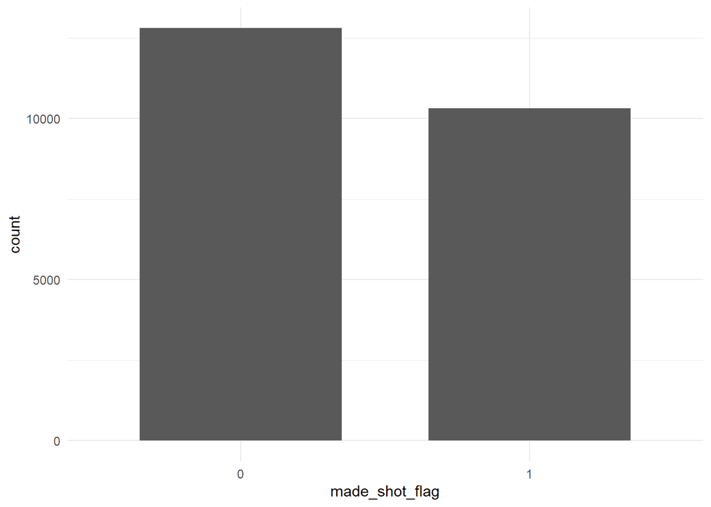

```r
ggplot(train, aes(x=factor(shot_made_flag)))+
  geom_bar(stat="count", width=0.7)+
  labs(
    x = "made_shot_flag",
    main = "the distribution of Kobe  Bryant Shots"
  )+
  theme_minimal()
```

To get more simplex model and reduce complexity of model, I will try eliminate some attributes.

```r
summary(train)
```

```
##        X                       action_type    combined_shot_type
##  Min.   :    1   Jump Shot           :14278   Bank Shot:  107
##  1st Qu.: 6434   Layup Shot          : 1919   Dunk     :  957
##  Median :12823   Driving Layup Shot  : 1453   Hook Shot:  116
##  Mean   :12839   Turnaround Jump Shot:  800   Jump Shot:17765
##  3rd Qu.:19246   Fadeaway Jump Shot  :  788   Layup    : 4042
##  Max.   :25697   Running Jump Shot   :  706   Tip Shot :  140
##                  (Other)             : 3183
##  game_event_id       game_id           lat            loc_x
##  2      :   91   20601081:   40   Min.   :33.25   Min.   :-250.0
##  11     :   74   21501228:   38   1st Qu.:33.88   1st Qu.: -69.5
##  4      :   72   20200069:   35   Median :33.97   Median :   0.0
##  12     :   71   20900527:   35   Mean   :33.95   Mean   :   6.9
##  17     :   71   20700553:   34   3rd Qu.:34.04   3rd Qu.:  94.0
##  278    :   70   20200127:   32   Max.   :34.09   Max.   : 248.0
##  (Other):22678   (Other) :22913
##      loc_y             lon         minutes_remaining     period     playoffs
##  Min.   :-43.00   Min.   :-118.5   Min.   : 0.00     Min.   :1.00   0:19755
##  1st Qu.:  4.00   1st Qu.:-118.3   1st Qu.: 2.00     1st Qu.:1.00   1: 3372
##  Median : 74.00   Median :-118.3   Median : 5.00     Median :3.00
##  Mean   : 91.59   Mean   :-118.3   Mean   : 4.87     Mean   :2.52
##  3rd Qu.:161.00   3rd Qu.:-118.2   3rd Qu.: 8.00     3rd Qu.:3.00
##  Max.   :791.00   Max.   :-118.0   Max.   :11.00     Max.   :7.00
##
##     season          seconds_remaining shot_distance  shot_made_flag
##  Length:23127       Min.   : 0.00     Min.   : 0.0   0:12809
##  Class :character   1st Qu.:13.00     1st Qu.: 5.0   1:10318
##  Mode  :character   Median :28.00     Median :15.0
##                     Mean   :28.29     Mean   :13.5
##                     3rd Qu.:43.00     3rd Qu.:21.0
##                     Max.   :59.00     Max.   :79.0
##
##           shot_type                   shot_zone_area
##  2PT Field Goal:18235   Back Court(BC)       :   66
##  3PT Field Goal: 4892   Center(C)            :10126
##                         Left Side Center(LC) : 3051
##                         Left Side(L)         : 2831
##                         Right Side Center(RC): 3585
##                         Right Side(R)        : 3468
##
##               shot_zone_basic        shot_zone_range       team_id
##  Above the Break 3    :4262   16-24 ft.      :6243   1610612747:23127
##  Backcourt            :  57   24+ ft.        :4771
##  In The Paint (Non-RA):3473   8-16 ft.       :5010
##  Left Corner 3        : 215   Back Court Shot:  66
##  Mid-Range            :9510   Less Than 8 ft.:7037
##  Restricted Area      :5307
##  Right Corner 3       : 303
##               team_name       game_date            matchup         opponent
##  Los Angeles Lakers:23127   Min.   : 9803   LAL @ SAS  :  773   SAS    : 1479
##                             1st Qu.:11835   LAL @ PHX  :  691   PHX    : 1392
##                             Median :13460   LAL vs. SAS:  687   SAC    : 1259
##                             Mean   :13347   LAL @ SAC  :  675   HOU    : 1248
##                             3rd Qu.:14684   LAL vs. PHX:  645   DEN    : 1192
##                             Max.   :16904   LAL vs. HOU:  640   POR    : 1185
##                                             (Other)    :19016   (Other):15372
```

**the variables do not have particular difference**

Since, Kobe Bryant only plays in LAL during his career, I exclude team_id and team_name.

Since, the matcups refers to which team opponet of LAL, I also exclude matchups. - the reason of matchups eliminated instead of opponent, the matchups make more complex models since it has also information which team is host.

**The time dependent variables**

game_id is determined by game_date and opponents,it is unique as much as game_date, I exclude game_id.

the game_event_id is very depend on time remaining and period and it has many category which makes models too complex I also exclude it.

**the distance depended variables:**

And, shot_zone_area, shot_zone_range, shot_zone_basic and shot_type variables is determined by location x, location y, and distance.

lag and lon variables very standart and changes in small, I think the accuracy of shots more dependent to distance between target not the size of target area. therefore, I also exclude them.

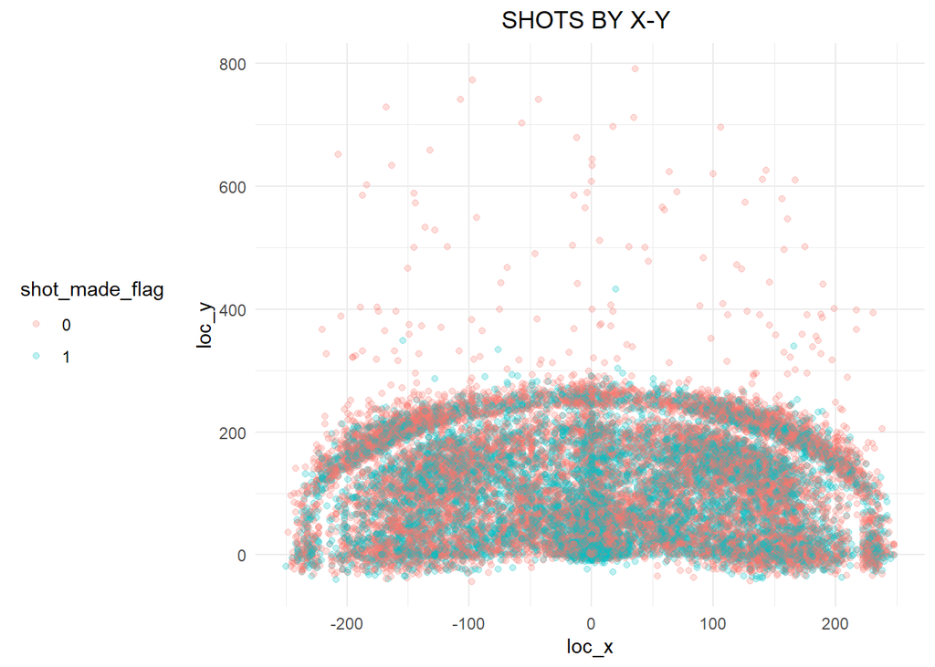

```r
 ggplot(train, aes(x=loc_x, y=loc_y)) +
  geom_point(aes(color=shot_made_flag), alpha= 0.25) +
  labs(title="SHOTS BY X-Y ") +
  theme_minimal() +
  theme(legend.position="left",
        plot.title=element_text(hjust=0.5))
```

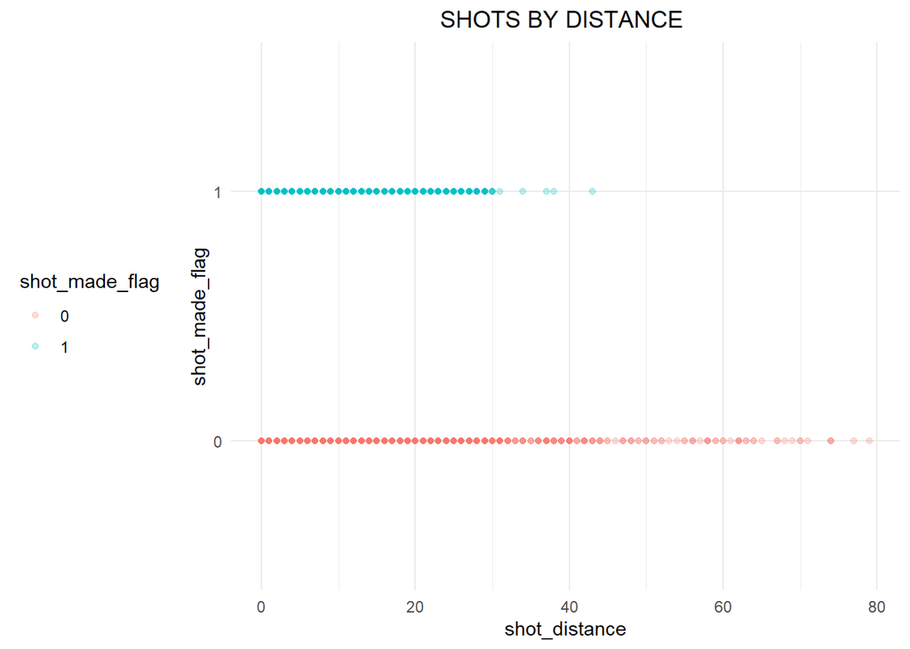

```r
 ggplot(train, aes(x= shot_distance, y=shot_made_flag)) +
  geom_point(aes(color=shot_made_flag), alpha= 0.25) +
  labs(title="SHOTS BY DISTANCE ") +
  theme_minimal() +
  theme(legend.position="left",
        plot.title=element_text(hjust=0.5))
```

```r
df <- train[,c("shot_made_flag","action_type","combined_shot_type", "loc_x", "loc_y","minutes_remaining","game_date", "period", "playoffs", "season", "seconds_remaining", "shot_distance", "opponent")]
test <- test[,c("X","action_type","combined_shot_type", "loc_x", "loc_y","minutes_remaining","game_date", "period", "playoffs", "season", "seconds_remaining", "shot_distance", "opponent")]
names(test) <- c("shot_made_flag","action_type","combined_shot_type", "loc_x", "loc_y","minutes_remaining","game_date", "period", "playoffs", "season", "seconds_remaining", "shot_distance", "opponent")
```